# Lab 2

Author

Maile Yamasaki

GitHub Link: https://github.com/maileyamasaki/Week_2

```python
import pandas as pd
from plotnine import ggplot, geom_point, aes, geom_boxplot, labs, geom_bar, facet_wrap, theme, element_text, scale_fill_discrete
import numpy as np
import matplotlib.pyplot as plt

df = pd.read_csv("/Users/maileyamasaki/Desktop/Cal Poly SLO/Machine Learning/Week_2/avocado-updated-2020.csv")
```

1. The table shows weekly sales data for Hass avocados extending from 2013 to 2020, including the number of units sold and the average price. The data comes from retailers’ cash registers and covers many store types. The average price is shown per avocado, even when they are sold in bags. The product codes (PLUs) only apply to Hass avocados.
2. Cleaning the data

```python
df = df.rename(columns={
    "4046": "small_hass",
    "4225": "large_hass",
    "4770": "xlarge_hass",
    "total_volume": "total_avocados"})

def categorize_region(region):
    if region == "Total U.S.":
        return "Total"
    elif region in ["West", "Northeast", "South", "Midwest", "Great Lakes", "Plains", "Midsouth"]:
        return "Region"
    elif region in ["California", "South Carolina", "New York"]:
        return "State"
    else:
        return "Metro"

df["region_type"] = df["geography"].apply(categorize_region)
```

3. Major geographical region selling the most total organic, small Hass avocados in 2017.

```python
df1 = df[(df["region_type"] == "Region") & (df["type"] == "organic") & (df["year"] == 2017)]

region_totals = (df1.groupby("geography")["small_hass"].sum())

top_region = region_totals.idxmax()
top_value = region_totals.max()

print(top_region)
print("total avocados:", top_value)
```

```
West
total avocados: 1870206.29
```

4. Month with highest average volume of avocado sales.

```python
df["date"] = pd.to_datetime(df["date"])

df["month"] = df["date"].dt.month
df["month_name"] = df["date"].dt.month_name()
df["day"] = df["date"].dt.day

monthly_avg = df.groupby("month_name")["total_avocados"].mean()

top_month = monthly_avg.idxmax()
top_value = monthly_avg.max()

print(top_month)
print("avaerage avocados:", top_value)
```

```
May
avaerage avocados: 1123632.254218107
```

5. Metro area geographical region with most total avocados.

```python
df2 = df[(df["region_type"] == "Metro")]

metro_totals = (df2.groupby("geography")["total_avocados"].sum())

top_metro = metro_totals.idxmax()
top_value = metro_totals.max()

print(top_metro)
print("total avocados:", top_value)
```

```
South Central
total avocados: 2075907887.55
```

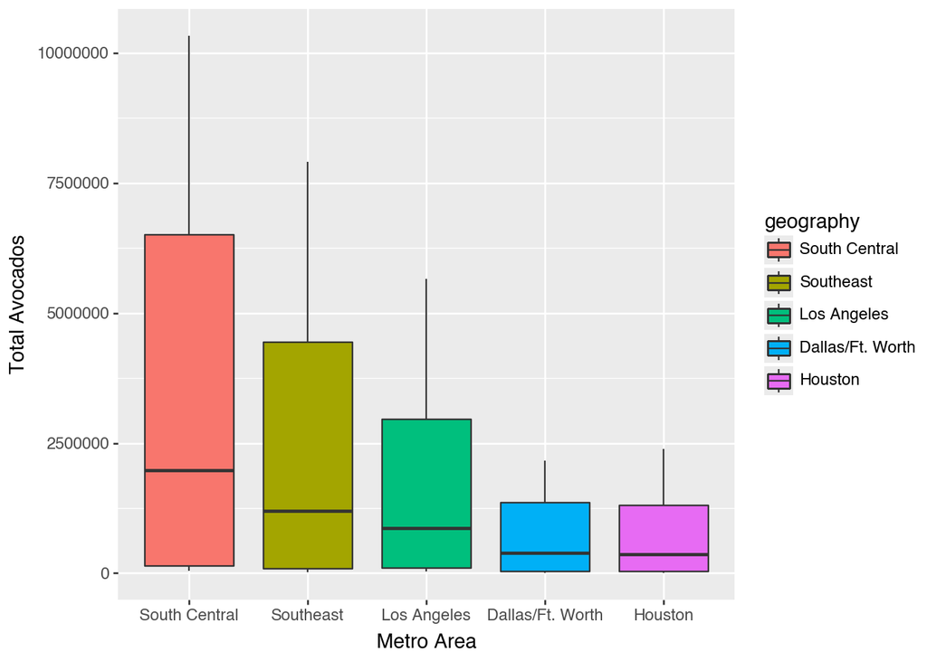

```python
metro_means = (df2.groupby("geography")["total_avocados"].mean().sort_values(ascending=False))

top5 = metro_means.head(5).index

df_top5 = df2[df2["geography"].isin(top5)].copy()
df_top5["geography"] = pd.Categorical(df_top5["geography"], categories=top5)

(ggplot(df_top5, aes(x = "geography", y = "total_avocados", fill = "geography"))
+ geom_boxplot()
+labs(x = "Metro Area", y = "Total Avocados"))
```

6. Dataset containing only the following geographies: “Los Angeles”, “San Diego”, “Sacramento”, and “San Francisco”.

```python
ca_cities = ["Los Angeles", "San Diego", "Sacramento", "San Francisco"]
df_ca = df[df["geography"].isin(ca_cities)]
```

7. California region where the price of organic vs conventional avocados varies the most.

```python
temp = (df_ca.groupby(["geography", "type"], as_index=False)["average_price"].mean())
df_ca1 = temp.pivot(index="geography", columns="type", values="average_price").reset_index()

df_ca1["average price difference"] = df_ca1["organic"] - df_ca1["conventional"]

greatest_diff = df_ca1["average price difference"].max()

id_greatest_diff = df_ca1["average price difference"].idxmax()
id = df_ca1["average price difference"].idxmax()
top_geo = df_ca1.loc[id, "geography"]

print(top_geo)
print("average price difference:", greatest_diff)
```

```
San Francisco
average price difference: 0.718954248366013
```

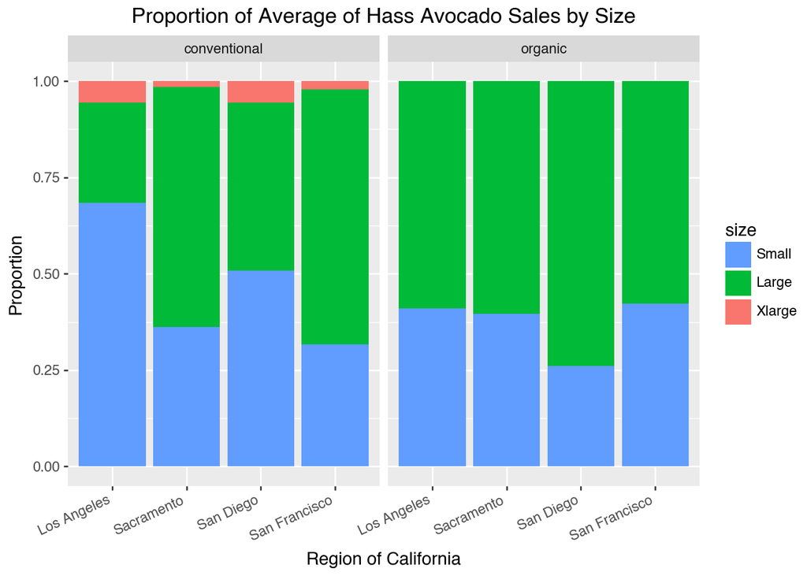

```python
sizes = ["xlarge_hass", "large_hass", "small_hass"]

df_ca2 = (df_ca.loc[df["geography"].isin(ca_cities), ["geography", "type"] + sizes].melt(id_vars=["geography", "type"],
            value_vars=sizes,
            var_name="size",
            value_name="vol")
)

df_ca2["size"] = pd.Categorical(df_ca2["size"], categories=sizes, ordered=True)

(ggplot(df_ca2, aes(
  x = "geography",
  y = "vol",
  fill = "size"
))
+ geom_bar(stat = "identity", position = "fill")
+ facet_wrap("~type")
+ labs(title = "Proportion of Average of Hass Avocado Sales by Size", x = "Region of California", y = "Proportion")
+ theme(axis_text_x=element_text(rotation=25, ha="right"))
+ scale_fill_discrete(
    breaks=["small_hass", "large_hass", "xlarge_hass"],
    labels=["Small", "Large", "Xlarge"])
)
```

9. Our vizualization displays Los Angeles as a major outlier among this data, but regarless, we see that there is a positive relationship between the average spending on avocados and the average housing prices. Thus we have reason to conclude that cities with higher average housing prices also have higher avocado spending, thus it may be more difficult to afford houses in these areas due to high cost and higher spending.

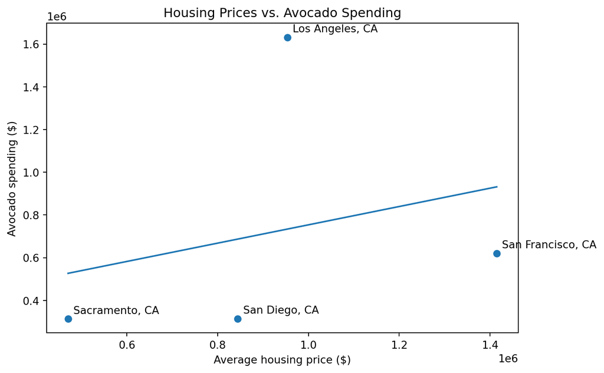

```python
df_housing = pd.read_csv("/Users/maileyamasaki/Desktop/Cal Poly SLO/Machine Learning/Week_2/med_sale_price.csv", encoding="utf-16", sep="\t")

df_ca3 = df_ca[["average_price", "geography", "total_avocados"]]
df_ca3["avo_spending"] = df_ca3["average_price"]*df_ca3["total_avocados"]

cities = ["Los Angeles", "San Francisco", "San Diego", "Sacramento"]

df_ca3 = (df_ca3.groupby("geography")["avo_spending"].mean())

df = pd.concat([df_housing.reset_index(drop=True),df_ca3.reset_index(drop=True)], axis=1)
df["avo_spending"] = df["avo_spending"].shift(1)

df = df.rename(columns={df.columns[0]: "city"}).copy()
if str(df.loc[0, "city"]).strip().lower() == "region":
    df = df.iloc[1:].reset_index(drop=True)

housing_cols = df.columns.difference(["city", "average_price", "avo_spending"])

df["avg_house_price"] = (
    df[housing_cols]
      .apply(lambda s: pd.to_numeric(
          s.astype(str).str.replace(r"[\$,]", "", regex=True).str.replace("K", ""),
          errors="coerce") * np.where(s.astype(str).str.endswith("K"), 1000, 1))
      .mean(axis=1)
)

x, y = df["avg_house_price"], df["avo_spending"]
m, b = np.polyfit(x, y, 1)

fig, ax = plt.subplots(figsize=(8,5))
ax.scatter(x, y)
ax.plot([x.min(), x.max()], [m*x.min()+b, m*x.max()+b])
for _, r in df.iterrows():
    ax.annotate(r["city"], (r["avg_house_price"], r["avo_spending"]), xytext=(5,5), textcoords="offset points")
ax.set(title="Housing Prices vs. Avocado Spending",
       xlabel="Average housing price ($)", ylabel="Avocado spending ($)")
plt.tight_layout()
plt.show()
```